# Projeto Patrícia Rodrigues

Autor

EstatMG - Empresa Júnior de Estatística e Ciências Atuariais da UFMG

Data de Publicação

21/12/2024

# Tratamento dos dados

O único tratamento significativo feito foi que na análise da Seção 4 em seguida, usou-se transformação logaritmica natural para expressar o tempo de resposta Pontanto, seja $y$ a variável resposta de interesse:

$$y = \ln(\text{Tempo de Reação})$$

# Tabela Resumo

Tabela 1: Tabela Resumo

| variavel | Participante | fator | Média TR | Des. Pad. TR |
| --- | --- | --- | --- | --- |
| Nível de surdez | ouvinte | nao se aplica | 1389.73 | 881.99 |
|  | surdo | profunda bilateral | 2351.20 | 2845.48 |
|  |  | profunda severa | 3460.30 | 2597.87 |
|  |  | severa bilateral | 1491.49 | 1158.37 |
| Idade | ouvinte | 10_12 | 1373.61 | 888.79 |
|  |  | 13_22 | 1494.52 | 830.26 |
|  | surdo | 10_12 | 2515.30 | 2743.00 |
|  |  | 13_22 | 2148.55 | 2270.86 |
| Sexo | ouvinte | F | 1468.51 | 1074.64 |
|  |  | M | 1299.70 | 576.71 |
|  | surdo | F | 1861.14 | 1740.46 |
|  |  | M | 2904.49 | 3136.98 |
| Grupo | ouvinte | Ensino Basico | 1373.61 | 888.79 |
|  |  | Final Ensino Basico | 1494.52 | 830.26 |
|  | surdo | Ensino Basico | 2503.44 | 2703.19 |
|  |  | Final Ensino Basico | 1711.21 | 1594.59 |
| Condição | ouvinte | Com relacao semantica | 1449.08 | 674.52 |
|  |  | Forte similaridade fonologica | 1533.41 | 1013.08 |
|  |  | Fraca similaridade fonologica | 1589.71 | 1027.19 |
|  |  | Iconicidade forte | 1202.81 | 643.83 |
|  |  | Iconicidade fraca | 1299.43 | 899.39 |
|  |  | Sem relacao semantica | 1541.20 | 1040.04 |
|  | surdo | Com relacao semantica | 2484.56 | 2349.78 |
|  |  | Forte similaridade fonologica | 2685.15 | 2574.05 |
|  |  | Fraca similaridade fonologica | 2716.68 | 2515.59 |
|  |  | Iconicidade forte | 2028.76 | 2252.81 |
|  |  | Iconicidade fraca | 2084.59 | 2226.48 |
|  |  | Sem relacao semantica | 2621.19 | 3525.99 |
| Acerto ou erro | ouvinte | certo | 1396.23 | 885.45 |
|  |  | errado | 1189.83 | 746.05 |
|  | surdo | certo | 2194.94 | 2358.82 |
|  |  | errado | 3046.53 | 3168.71 |

## Nível de surdez

Pela Tabela 1, surdez profunda bilateral apresenta alta variabilidade (desvio padrão alto), sugerindo que alguns indivíduos podem responder de forma muito diferente dentro do mesmo grupo e profundidade severa tem a maior media no tempo de reação.

## Idade

Pela Tabela 1, surdos têm TRs médios mais altos e maior dispersão em ambas as faixas etárias. No entanto, o TR médio diminui na faixa de 13-22 anos.

## Sexo

Pela Tabela 1, homens surdos têm a média de TR mais alta e a maior variabilidade, apontando para uma grande dispersão nos dados e mulheres surdas têm média de TR alta, mas menor que a dos homens surdos, com variação considerável.

## Grupo

Pela Tabela 1, surdos apresentam TRs médios mais altos, mas com uma redução notável no final do Ensino Básico, tanto na média quanto na dispersão.

## Condição

Pela Tabela 1, surdos apresentam tempos de reação consistentemente mais altos e dispersão maior do que os ouvintes em todas as condições. As condições forte e fraca similaridade fonológica e sem relação semântica mostram os maiores TRs médios e dispersões, enquanto iconicidade forte tem os menores.

## Acerto ou erro

# Hipóteses a serem discutidas

## Hipótese 1: Coativação linguística, Libras e Língua Portuguesa, em surdos (independente da condição)

Essa hipótese seria evidenciada por maior tempo de reação (TR) se comparado com participantes ouvintes. O TR ocorreria supostamente devido ao esforço cognitivo de suprimir a Libras durante o teste. Sugestão: comparar acertos e erros entre participantes surdos e ouvintes, verificando o tempo de reação (TR).

**Resposta se encontra presente na Seção 4.1**.

## Hipótese 2: Efeito de facilitação ou inibição linguística (participantes surdos)

- O efeito de facilitação se evidenciaria caso o TR da Condição 1 (iconicidade forte) fosse menor comparado ao TR da Condição 2 (iconicidade fraca). Além disso, a Condição 1 teria menos erros se comparado a Condição 2.
- O efeito de inibição ocorreria caso o TR da Condição 3 (forte similaridade fonológica) fosse maior comparado ao TR da Condição 4 (forte similaridade fonológica). Além disso, a Condição 3 apresentaria mais erros se comparado a Condição 4.

Os efeitos da hipótese 2 não seriam observados nos participantes ouvintes

**Resposta se encontra presente na Seção 4.2**.

## Hipótese 3: Surdos do Grupo 1 apresentam menos controle inibitório linguístico se comparado ao Grupo 2

Comparação de TR entre grupo 1 e grupo 2 para verificação se há diferença significativa entre os grupos. Se a hipótese estiver correta os surdos do grupo 1 terão TR maior se comparado aos do grupo 2.

- Grupo 1: alunos do 5º, 6º, 7º ou 8º ano do Ensino Básico
- Grupo 2: alunos do 9º, 1º, 2º ou 3º ano do Final do Ensino Básico.

**Resposta se encontra presente na Seção 4.3**.

# ANOVA

A análise de variância (ANOVA) foi realizada com o intuito de investigar o impacto de diversas variáveis sobre o tempo de reação. A hipótese geral de cada variável é:

Quando obervava-se um $P-valor < 0.05$, indicava rejeição de $H_{0}$ e implicava que pelo menos um nível da variável analisada tinha efeito sobre a variável resposta. Essas variáveis que foram significativas, junto ao $P-valor$, estão sinalizadas por asterisco (*) ou ponto (.) na tabela de resultados.

Se, e somente se, o teste indicasse rejeição da Hipótese Nula, então aplicava-se o teste de Comparações Múltiplas o qual seria possível confirmar qual nível da variável está influenciando mais na resposta, no caso, Tempo de Reação.

$$\begin{eqnarray}
{
\left\{\begin{array}{lcc}
H_{0}: \text{A variável não influencia na resposta, }\mu = 0 \\
H_{1}: \text{pelo menos um nível (i) da variável influencia na resposta, }\mu_{i} \neq 0
\end{array}\right.
} \nonumber
\end{eqnarray}$$

Tabela 2: Tabela Anova para Tempo de Reação em escala logaritmica

| Covariável | gl | SQ | MQ | F | Pvalor |
| --- | --- | --- | --- | --- | --- |
| Participante | 1 | 106.098 | 106.098 | 291.063 | <0.001* |
| Nivel_surdez | 2 | 143.868 | 71.934 | 197.339 | <0.001* |
| Grupo | 1 | 1.799 | 1.799 | 4.934 | 0.026* |
| Condicao | 5 | 48.582 | 9.716 | 26.655 | <0.001* |
| Acerto_erro | 1 | 0.393 | 0.393 | 1.078 | 0.299 |
| Idadecat | 1 | 1.777 | 1.777 | 4.874 | 0.027* |
| Participante : Acerto_erro | 1 | 7.702 | 7.702 | 21.13 | <0.001* |
| Condicao : Acerto_erro | 5 | 3.492 | 0.698 | 1.916 | 0.088. |
| Participante : Grupo | 1 | 12.367 | 12.367 | 33.926 | <0.001* |
| Residuals | 4,269 | 1,556.137 | 0.365 |  |  |

Significativo a 5% de significância e '.' significativo a 10%

## Hipótese 1

Tabela 3: Tabela de comparações múltiplas para Tempo de Reação com fator de participante e tipo de resposta

| Fator1 | Fator2 | Diferença | Pvalor |
| --- | --- | --- | --- |
| ouvinte - ouvinte | errado : certo | -0.273 | 0.001* |
| ouvinte - surdo | errado : certo | -0.562 | <0.001* |
| surdo - ouvinte | certo : certo | 0.289 | <0.001* |
|  | errado : certo | 0.386 | <0.001* |
|  | errado : errado | 0.659 | <0.001* |
| surdo - surdo | errado : certo | 0.097 | 0.027* |

Nota: Fator1 refere a Participante e Fator2 a acerto_erro  
* significativo a 5% de significância e '.' significativo a 10%

## Hipótese 2

A Tabela 2 revela que a interação Condicao:Acerto_erro não foi significativa ao nível de significânica de 5%, mas atingiu significância ao nível de 10%. Contudo, ao examinar as comparações específicas dentro dessa interação presente na Tabela 4, não foram identificadas diferenças estatisticamente significativas nos tempos de reação entre as condições de *“Iconicidade forte” e “Iconicidade fraca”*, nem entre *“Forte similaridade fonológica” e “Fraca similaridade fonológica”*.

Tabela 4: Tabela de comparações múltiplas para Tempo de Reação com fator de condição e tipo de resposta

| Fator1 | Fator2 | Diferença | Pvalor |
| --- | --- | --- | --- |
| Com relacao semantica - Com relacao semantica | errado : certo | 0.016 | 1.000 |
| Com relacao semantica - Forte similaridade fonologica | errado : certo | -0.019 | 1.000 |
| Com relacao semantica - Fraca similaridade fonologica | errado : certo | -0.050 | 1.000 |
| Com relacao semantica - Iconicidade forte | errado : certo | 0.226 | 0.061. |
| Com relacao semantica - Iconicidade fraca | errado : certo | 0.181 | 0.300 |
| Com relacao semantica - Sem relacao semantica | errado : certo | 0.016 | 1.000 |
| Forte similaridade fonologica - Com relacao semantica | certo : certo | 0.035 | 0.999 |
|  | errado : certo | -0.117 | 0.882 |
|  | errado : errado | -0.133 | 0.959 |
| Forte similaridade fonologica - Forte similaridade fonologica | errado : certo | -0.152 | 0.579 |
| Forte similaridade fonologica - Fraca similaridade fonologica | errado : certo | -0.184 | 0.272 |
| Forte similaridade fonologica - Iconicidade forte | errado : certo | 0.093 | 0.966 |
| Forte similaridade fonologica - Iconicidade fraca | errado : certo | 0.048 | 1.000 |
| Forte similaridade fonologica - Sem relacao semantica | errado : certo | -0.117 | 0.881 |
| Fraca similaridade fonologica - Com relacao semantica | certo : certo | 0.066 | 0.886 |
|  | errado : certo | 0.117 | 0.920 |
|  | errado : errado | 0.101 | 0.997 |
| Fraca similaridade fonologica - Forte similaridade fonologica | certo : certo | 0.032 | 1.000 |
|  | errado : certo | 0.082 | 0.995 |
|  | errado : errado | 0.234 | 0.349 |
| Fraca similaridade fonologica - Fraca similaridade fonologica | errado : certo | 0.051 | 1.000 |
| Fraca similaridade fonologica - Iconicidade forte | errado : certo | 0.327 | <0.001* |
| Fraca similaridade fonologica - Iconicidade fraca | errado : certo | 0.282 | 0.005* |
| Fraca similaridade fonologica - Sem relacao semantica | errado : certo | 0.117 | 0.916 |
| Iconicidade forte - Com relacao semantica | certo : certo | -0.210 | <0.001* |
|  | errado : certo | -0.144 | 0.794 |
|  | errado : errado | -0.159 | 0.908 |
| Iconicidade forte - Forte similaridade fonologica | certo : certo | -0.245 | <0.001* |
|  | errado : certo | -0.178 | 0.488 |
|  | errado : errado | -0.026 | 1.000 |
| Iconicidade forte - Fraca similaridade fonologica | certo : certo | -0.277 | <0.001* |
|  | errado : certo | -0.210 | 0.230 |
|  | errado : errado | -0.261 | 0.278 |
| Iconicidade forte - Iconicidade forte | errado : certo | 0.067 | 0.999 |
| Iconicidade forte - Iconicidade fraca | errado : certo | 0.022 | 1.000 |
| Iconicidade forte - Sem relacao semantica | errado : certo | -0.143 | 0.793 |
| Iconicidade fraca - Com relacao semantica | certo : certo | -0.165 | <0.001* |
|  | errado : certo | -0.050 | 1.000 |
|  | errado : errado | -0.065 | 1.000 |
| Iconicidade fraca - Forte similaridade fonologica | certo : certo | -0.200 | <0.001* |
|  | errado : certo | -0.084 | 0.995 |
|  | errado : errado | 0.068 | 1.000 |
| Iconicidade fraca - Fraca similaridade fonologica | certo : certo | -0.231 | <0.001* |
|  | errado : certo | -0.116 | 0.937 |
|  | errado : errado | -0.166 | 0.877 |
| Iconicidade fraca - Iconicidade forte | certo : certo | 0.045 | 0.881 |
|  | errado : certo | 0.161 | 0.562 |
|  | errado : errado | 0.094 | 0.999 |
| Iconicidade fraca - Iconicidade fraca | errado : certo | 0.116 | 0.920 |
| Iconicidade fraca - Sem relacao semantica | errado : certo | -0.049 | 1.000 |
| Sem relacao semantica - Com relacao semantica | certo : certo | 0.000 | 1.000 |
|  | errado : certo | 0.128 | 0.954 |
|  | errado : errado | 0.112 | 0.997 |
| Sem relacao semantica - Forte similaridade fonologica | certo : certo | -0.035 | 0.999 |
|  | errado : certo | 0.093 | 0.996 |
|  | errado : errado | 0.245 | 0.462 |
| Sem relacao semantica - Fraca similaridade fonologica | certo : certo | -0.067 | 0.871 |
|  | errado : certo | 0.061 | 1.000 |
|  | errado : errado | 0.011 | 1.000 |
| Sem relacao semantica - Iconicidade forte | certo : certo | 0.210 | <0.001* |
|  | errado : certo | 0.338 | 0.005* |
|  | errado : errado | 0.271 | 0.374 |
| Sem relacao semantica - Iconicidade fraca | certo : certo | 0.165 | <0.001* |
|  | errado : certo | 0.293 | 0.032* |
|  | errado : errado | 0.177 | 0.905 |
| Sem relacao semantica - Sem relacao semantica | errado : certo | 0.128 | 0.953 |

Nota: Fator1 refere a condicao e Fator2 a acerto_erro  
* significativo a 5% de significância e '.' significativo a 10%

É importante acrescentar que, desconsiderando a resposta estar correta ou não, que chamamos de efeito marginal, segundo a Tabela 8 o resultado é o mesmo, pois não há diferença significativa desses grupos na variável resposta. Em suma, são estatisticamente iguais.

## Hipótese 3

Por fim, pela Tabela 2, nota-se que a interação Participante:Grupo apresentou significância estatística, destacando variações relevantes no desempenho entre os grupos. Pela Tabela 5, especificamente, nota-se no nível “surdo - surdo”, observou-se que o grupo “Ensino Básico” apresentou tempos de reação maiores em comparação ao grupo “Final Ensino Básico”, sugerindo diferenças relevantes no processamento entre esses subgrupos.

Tabela 5: Tabela de comparações múltiplas para Tempo de Reação com fator de participante e grupo

| Fator1 | Fator2 | Diferença | Pvalor |
| --- | --- | --- | --- |
| ouvinte - ouvinte | Final Ensino Basico : Ensino Basico | 0.095 | 0.062. |
| ouvinte - surdo | Final Ensino Basico : Ensino Basico | -0.264 | <0.001* |
| surdo - ouvinte | Ensino Basico : Ensino Basico | 0.359 | <0.001* |
|  | Final Ensino Basico : Ensino Basico | 0.202 | <0.001* |
|  | Final Ensino Basico : Final Ensino Basico | 0.107 | 0.093. |
| surdo - surdo | Final Ensino Basico : Ensino Basico | -0.157 | <0.001* |

Nota: Fator1 refere a Participante e Fator2 a Grupo  
* significativo a 5% de significância e '.' significativo a 10%

Novamente, de forma marginal, quem está no Ensino básico sempre demora mais para resposder do que o outro grupo, como segue na Tabela 7.

## Comparações marginais

### Participante

Tabela 6

| Fator1 | Diferença | Pvalor |
| --- | --- | --- |
| surdo - ouvinte | 0.315 | <0.001* |

Nota: Fator1 refere a Participante  
* significativo a 5% de significância e ‘.’ significativo a 10%

Comparação múltipla para participantes

Pela Tabela 6, em geral, participantes surdos demoram mais para responder em relação aos ouvintes.

### Nível de Surdez

| Fator1 | Diferença | Pvalor |
| --- | --- | --- |
| profunda bilateral - nao se aplica | -0.040 | 0.276 |
| profunda severa - nao se aplica | 0.476 | <0.001* |
| profunda severa - profunda bilateral | 0.516 | <0.001* |
| severa bilateral - nao se aplica | -0.278 | <0.001* |
| severa bilateral - profunda bilateral | -0.238 | <0.001* |
| severa bilateral - profunda severa | -0.754 | <0.001* |

Nota: Fator1 refere a Nivel_Surdez  
* significativo a 5% de significância e '.' significativo a 10%

### Grupo

Tabela 7: Tabela de comparações múltiplas para Tempo de Reação com fator grupo

| Fator1 | Diferença | Pvalor |
| --- | --- | --- |
| Final Ensino Basico - Ensino Basico | -0.051 | 0.039* |

Nota: Fator1 refere a Grupo  
* significativo a 5% de significância e '.' significativo a 10%

### Condição

Tabela 8: Tabela de comparações múltiplas para Tempo de Reação com fator de condição

| Fator1 | Diferença | Pvalor |
| --- | --- | --- |
| Forte similaridade fonologica - Com relacao semantica | 0.007 | 1.000 |
| Fraca similaridade fonologica - Com relacao semantica | 0.071 | 0.384 |
| Fraca similaridade fonologica - Forte similaridade fonologica | 0.064 | 0.510 |
| Iconicidade forte - Com relacao semantica | -0.208 | <0.001* |
| Iconicidade forte - Forte similaridade fonologica | -0.216 | <0.001* |
| Iconicidade forte - Fraca similaridade fonologica | -0.280 | <0.001* |
| Iconicidade fraca - Com relacao semantica | -0.160 | <0.001* |
| Iconicidade fraca - Forte similaridade fonologica | -0.167 | <0.001* |
| Iconicidade fraca - Fraca similaridade fonologica | -0.231 | <0.001* |
| Iconicidade fraca - Iconicidade forte | 0.049 | 0.425 |
| Sem relacao semantica - Com relacao semantica | 0.010 | 1.000 |
| Sem relacao semantica - Forte similaridade fonologica | 0.002 | 1.000 |
| Sem relacao semantica - Fraca similaridade fonologica | -0.061 | 0.555 |
| Sem relacao semantica - Iconicidade forte | 0.218 | <0.001* |
| Sem relacao semantica - Iconicidade fraca | 0.170 | <0.001* |

Nota: Fator1 refere a condicao  
* significativo a 5% de significância e '.' significativo a 10%

### Idade categorizada

| Fator1 | Diferença | Pvalor |
| --- | --- | --- |
| 13_22 - 10_12 | 0.029 | 0.147 |

Nota: Fator1 refere a idadecat  
* significativo a 5% de significância e '.' significativo a 10%

## Pressupostos

Pela Figura 1, nota-se que em geral há homocedasticidade pelo ajuste da ANOVA, assim, garante-se variância constante. Ainda, pela Figura 2, olhando os resíduos em cada bloco de comparações por fatores feitas, nota-se que há um aumento da variabilidade dos grupos que envolvem a variável de resposta errada. Entretanto, olhando pro último gráfico de *condição:acerto/erro* nota-se que todas condições cujo tipo de resposta foi erro possuem maior variabilidade, ou seja, embora haja aumento de variabilidade nesse grupo, esse aumento é constante em todas condições. Em resumo, entende-se que o pressuposto de variância constantes nos grupos é válida. Sobre a normalidade, tanto pela Figura 1 que mostra que os dados mais extremos fogem da sobreposição da ‘linha preta’, ou seja, nas caudas foge-se do padrão de normalidade. Entretanto, dado o grande volume de dados, isso é esperado. O histograma indica certa simetria entre os resíduos o que é possível ser visto nos gráficos Figura 2. Logo, sem perda de generalidade, aceita-se ambas suposições.

Figura 1: Gráfico de resíduos geral

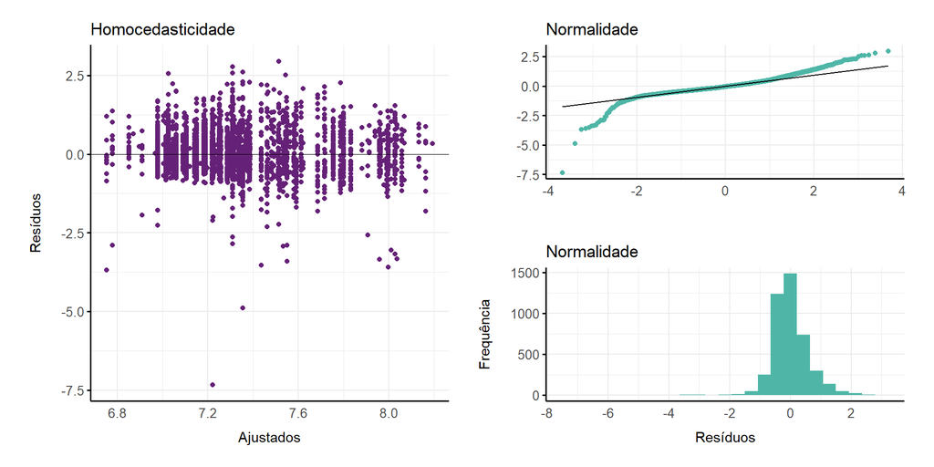

Figura 2: Gráfico de resíduos padronizados por variável

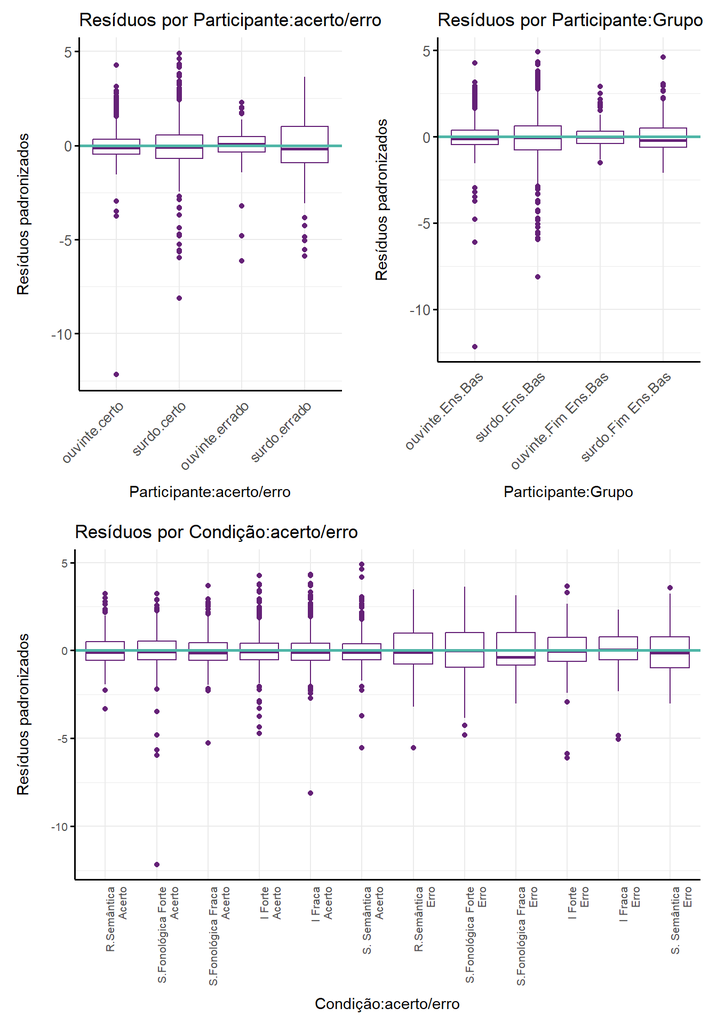